# Experimento com Matéria Patrocinada

Insper - Programa Avançado em Data Science - Marketing Analytics

Guilherme Nogueira e Viviane Sanchez

10/17/2020 - 10/01/2020

# 1. Introdução

O objetivo desta análise é avaliar a influência do patrocínio de matérias. Através de métodos inferenciais estatísticos serão avaliados os seguintes itens:

- Diferença entre características dos consumidores
- Credibilidade da pessoa patrocinada para fazer a matéria (A)
- Atitude em relação à marca patrocinada (B)
- Impacto em pessoas mais envolvidas com a marca (C)

## 1.1. Pacotes

```r
library(tidyverse)
library(moments)
library(DescTools)
library(skimr)
library(lubridate)
library(janitor)
library(ggpubr)
library(ggpmisc)
library(psych)
library(ggpubr)
library(factoextra)
library(devtools)
library(factoextra)

today <- Sys.Date()

theme_set(theme_minimal())
theme_update(plot.title = element_text(face = "bold", size = 16))
```

# 2. Dados

Após a leitura da base de dados, as variáveis de características são transformadas no formato tidy com `pivot_longer` para as colunas `grupo_caract` e `caract`.

```r
load("data/experimento_mat.RData")

skim(experimento_mat)
```

Data summary

| Name | experimento_mat |
| --- | --- |
| Number of rows | 149 |
| Number of columns | 11 |
| _______________________ |  |
| Column type frequency: |  |
| factor | 4 |
| numeric | 7 |
| ________________________ |  |
| Group variables | None |

**Variable type: factor**

| skim_variable | n_missing | complete_rate | ordered | n_unique | top_counts |
| --- | --- | --- | --- | --- | --- |
| EST_CIVIL | 0 | 1.00 | FALSE | 5 | 1: 99, 2: 36, 3: 10, 4: 3 |
| RENDA | 0 | 1.00 | FALSE | 7 | 7: 42, 6: 32, 4: 26, 3: 20 |
| ESCOLARIDADE | 1 | 0.99 | FALSE | 4 | 6: 55, 4: 45, 5: 42, 3: 6 |
| IV_MATERIA_PATR | 0 | 1.00 | FALSE | 2 | 1: 78, 0: 71 |

**Variable type: numeric**

| skim_variable | n_missing | complete_rate | mean | sd | p0 | p25 | p50 | p75 | p100 | hist |
| --- | --- | --- | --- | --- | --- | --- | --- | --- | --- | --- |
| ID | 0 | 1.00 | 75.00 | 43.16 | 1.00 | 38.00 | 75.00 | 112.00 | 149 | ▇▇▇▇▇ |
| ANO_NASCTO | 1 | 0.99 | 1985.22 | 8.10 | 1952.00 | 1981.00 | 1987.00 | 1990.25 | 1996 | ▁▁▂▆▇ |
| CRED_T1 | 0 | 1.00 | 5.05 | 1.35 | 1.00 | 4.00 | 5.00 | 6.00 | 7 | ▁▂▆▅▇ |
| CRED_T2 | 0 | 1.00 | 4.19 | 1.80 | 1.00 | 3.00 | 4.00 | 6.00 | 7 | ▆▃▅▅▇ |
| ATIT_T1 | 0 | 1.00 | 6.31 | 0.80 | 4.00 | 6.00 | 6.50 | 7.00 | 7 | ▁▁▁▃▇ |
| ATIT_T2 | 0 | 1.00 | 5.53 | 1.39 | 2.00 | 4.33 | 6.00 | 7.00 | 7 | ▁▃▃▅▇ |
| ENVOLVIMENTO | 0 | 1.00 | 5.45 | 1.14 | 1.33 | 4.67 | 5.33 | 6.33 | 7 | ▁▁▅▇▇ |

```r
exp_raw <- experimento_mat %>%
  as_tibble() %>%
  clean_names() %>%
  na.omit()

exp <- exp_raw %>%
  mutate(idade = year(today) - ano_nascto,
         faixa_et = as_factor(ntile(idade, 5)))

exp_pivot <- exp %>%
  pivot_longer(cols = c(renda, escolaridade, est_civil, faixa_et),
                        names_to = "caract",
                        values_to = "grupo_caract")
```

# 3. Análise

## 3.1 Diferenças entre características

Para melhor entender as diferenças entre as carcaterísticas, será aplicado o teste qui-quadrado.

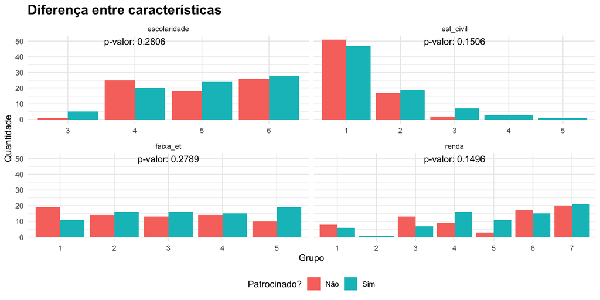

```r
p_est <- exp %>%
  tabyl(est_civil, iv_materia_patr) %>%
  chisq.test()

p_esc <- exp %>%
  tabyl(escolaridade, iv_materia_patr) %>%
  chisq.test()

p_renda <- exp %>%
  tabyl(renda, iv_materia_patr) %>%
  chisq.test()

p_idade <- exp %>%
  tabyl(faixa_et, iv_materia_patr) %>%
  chisq.test()

p_values <- tibble(
  label = c(p_esc$p.value, p_est$p.value, p_renda$p.value, p_idade$p.value),
  caract   = c("escolaridade", "est_civil", "renda", "faixa_et"),
  x = c("4", "3", "4", "3"),
  y = 50,
  iv_materia_patr = 0)

exp_pivot %>%
  group_by(caract, grupo_caract, iv_materia_patr) %>%
  count() %>%
  ggplot(aes(grupo_caract, n, fill = if_else(iv_materia_patr == 0, "Não", "Sim"))) +
  geom_col(position = "dodge") +
  facet_wrap(~caract, scales = "free_x") +
  theme(legend.position = "bottom") +
  labs(title = "Diferença entre características",
       x = "Grupo", y = "Quantidade", fill = "Patrocinado?") +
  geom_text(data = p_values,
            mapping = aes(x = x, y = y,
                          label = paste("p-valor:",
                                        round(label, 4))))
```

Considerando os p-valores do teste qui-quadrado para cada grupo, não é possível afirmar que existe uma diferença entre eles.

## 3.2. Verificação de Hipóteses

### 3.2.1. Hipótese A

Será verificada a validade da seguinte hipótese:

- O fato da matéria ser patrocinada (A) diminui a credibilidade da blogueira.

```r
exp_pivot <- exp_pivot %>% mutate(delta_cred = cred_t2-cred_t1)


anova_hip_a_cred <- exp_pivot %>%
  aov(delta_cred ~ iv_materia_patr, data = .)

summary(anova_hip_a_cred)
```

```
##                  Df Sum Sq Mean Sq F value Pr(>F)
## iv_materia_patr   1  387.1   387.1   149.5 <2e-16 ***
## Residuals       586 1517.2     2.6
## ---
## Signif. codes:  0 '***' 0.001 '**' 0.01 '*' 0.05 '.' 0.1 ' ' 1
```

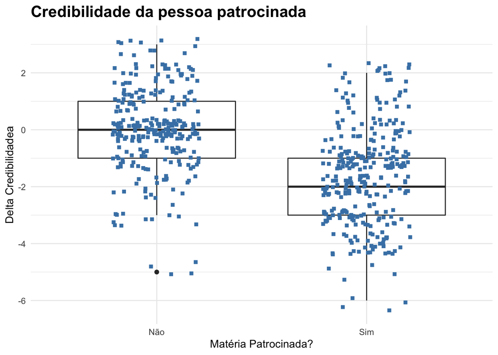

```r
ggplot(exp_pivot, aes(y = delta_cred,
                      x = if_else(iv_materia_patr == 0,
                                                  "Não", "Sim"))) +
  geom_boxplot() +
  geom_jitter(shape = 15,
              color = "steelblue",
              position = position_jitter(0.21)) +
  labs(title = "Credibilidade da pessoa patrocinada", y = "Delta Credibilidadea",
       x = "Matéria Patrocinada?")
```

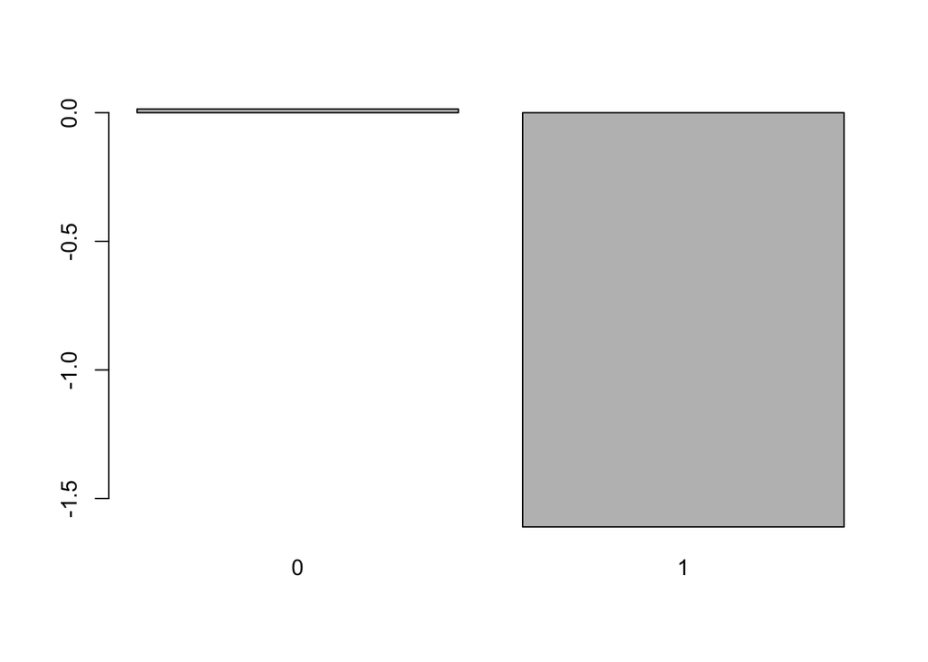

```r
barplot(tapply(exp_pivot$delta_cred,exp_pivot$iv_materia_patr, mean))
```

Com base no teste da ANOVA podemos ver que existe uma queda na credibilidade do digital influencer quando este realiza uma matéria patrocinada.

### 3.2.2. Hipótese B

Será verificada a validade da seguinte hipótese:

- O fato da matéria ser patrocinada diminui a atitude com relação à marca que patrocinou.

```r
exp_pivot <- exp_pivot %>%
  mutate(delta_atit = atit_t2-atit_t1)


anova_hip_b_atit <- exp_pivot %>%
  aov(delta_atit ~ iv_materia_patr, data = .)

summary(anova_hip_b_atit)
```

```
##                  Df Sum Sq Mean Sq F value Pr(>F)
## iv_materia_patr   1  237.9  237.90     161 <2e-16 ***
## Residuals       586  865.6    1.48
## ---
## Signif. codes:  0 '***' 0.001 '**' 0.01 '*' 0.05 '.' 0.1 ' ' 1
```

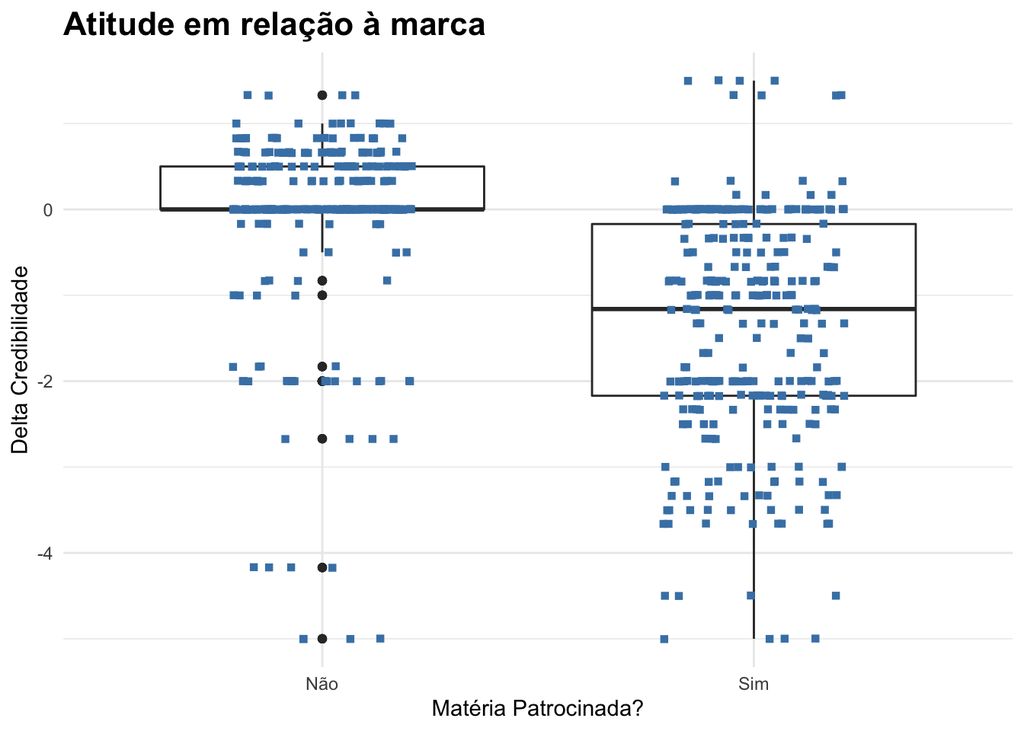

```r
ggplot(exp_pivot, aes(y = delta_atit, x = if_else(iv_materia_patr == 0,
                                                  "Não", "Sim"))) +
  geom_boxplot() +
  geom_jitter(shape = 15,
              color = "steelblue",
              position = position_jitter(0.21)) +
   labs(title = "Atitude em relação à marca", y = "Delta Credibilidade",
       x = "Matéria Patrocinada?")
```

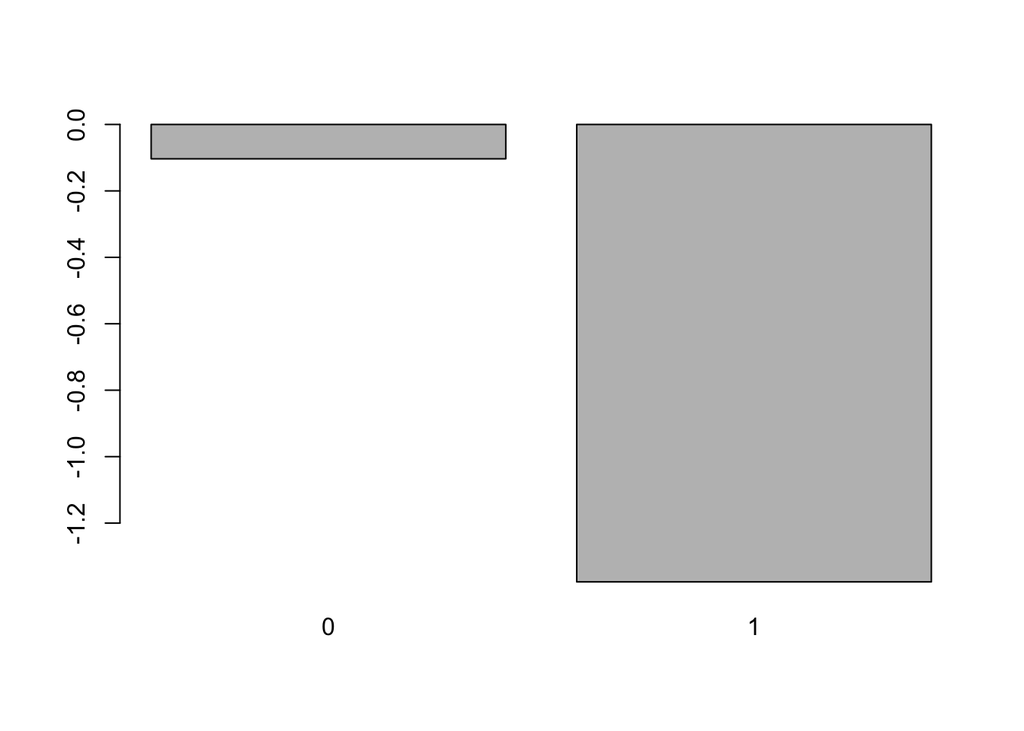

```r
barplot(tapply(exp_pivot$delta_atit,exp_pivot$iv_materia_patr, mean))
```

Com base no teste da ANOVA observa-se uma queda na atitude com relação à marca quando esta realiza uma matéria patrocinada.

### 3.2.3. Hipótese C

Será verificada a validade da seguinte hipótese:

- Pessoas mais envolvidas com o produto são menos afetadas por esse tipo de matéria.

```r
exp_pivot_patr <- exp_pivot %>%
  filter(iv_materia_patr == 1)

exp_pivot_patr <- exp_pivot_patr %>%
  mutate(envolvimento_grupo = case_when(
            envolvimento <= 4 ~ 'baixo envolvimento',
            envolvimento > 4  ~ 'alto envolvimento'
))


anova_hip_c_atit_env <- exp_pivot_patr %>%
  aov( delta_atit ~ envolvimento_grupo, data = .)

summary(anova_hip_c_atit_env)
```

```
##                     Df Sum Sq Mean Sq F value Pr(>F)
## envolvimento_grupo   1    2.3   2.348   1.345  0.247
## Residuals          306  534.4   1.746
```

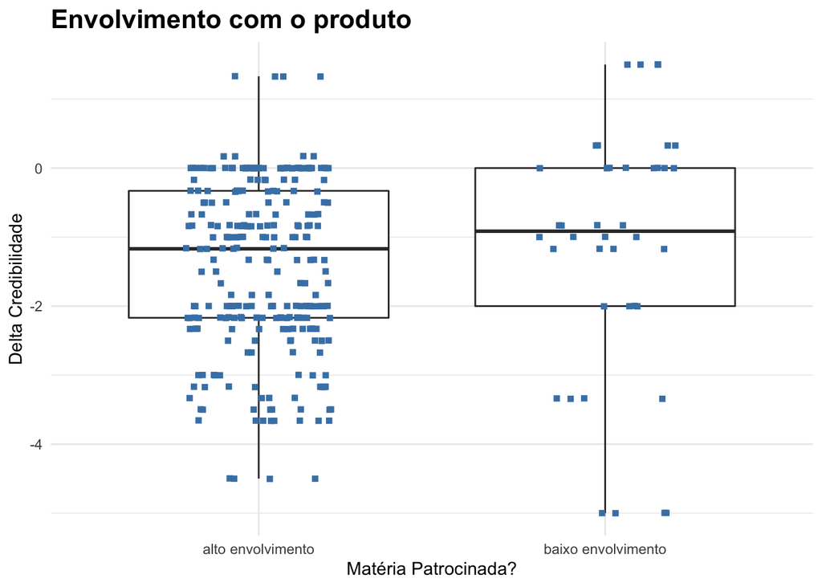

```r
ggplot(exp_pivot_patr, aes(y = delta_atit, x = envolvimento_grupo)) +
  geom_boxplot() +
  geom_jitter(shape = 15,
              color = "steelblue",
              position = position_jitter(0.21)) +
  labs(title = "Envolvimento com o produto", y = "Delta Credibilidade",
       x = "Matéria Patrocinada?")
```

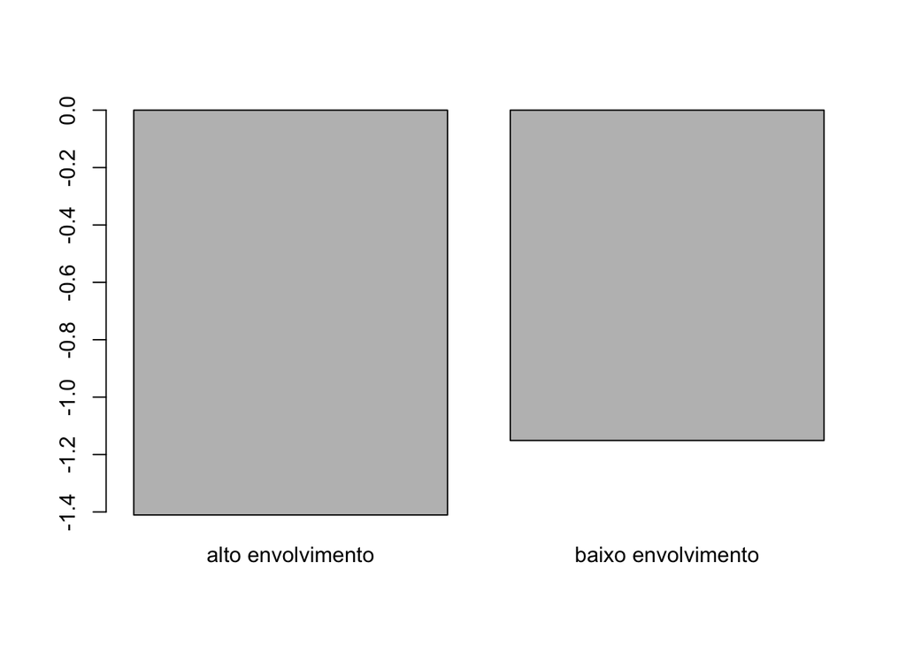

```r
barplot(tapply(exp_pivot_patr$delta_atit,exp_pivot_patr$envolvimento_grupo,mean))
```

```r
pairwise.t.test(exp_pivot_patr$delta_atit,
                exp_pivot_patr$envolvimento_grupo,
                data = exp_pivot_patr,
                p.adjust.method = "bonferroni")
```

```
##
##  Pairwise comparisons using t tests with pooled SD
##
## data:  exp_pivot_patr$delta_atit and exp_pivot_patr$envolvimento_grupo
##
##                    alto envolvimento
## baixo envolvimento 0.25
##
## P value adjustment method: bonferroni
```

Com base nesta quebra de envolvimento não há significância estatística para diferenciar o impacto na atitude entre os grupos com maior e menor envolvimento para uma matéria patrocinada.

# 4. Referências

- Material de aula do curso Marketing Analytics